# 언어심리학을 위한 데이터 사이언스 5주차: 데이터 사이언스 #3 (데이터 시각화)

## (12) 범주변수를 색상으로 표현하기

- `col` 논항: `geom_point` 함수의 `col` 논항을 사용하면 관찰값 포인트의 색상을 바꿀 수 있음.

```r
# geom_point 레이어만 빼고 이전과 동일하게 ggplot 객체 정의하여 p 변수에 할당하기.
p <- murders %>%
  ggplot(aes(population/10^6, total, label = abb)) +
  geom_text(nudge_x = 0.05) +
  scale_x_log10() +
  scale_y_log10() +
  xlab("100만 단위 인구 수(로그 척도)") +
  ylab("전체 총기살인 사건 수(로그 척도)") +
  ggtitle("2010년 미국 총기 살인사건 현황")
```

- `geom_point` 레이어 추가: `color/colour` 논항을 추가하여 모든 관찰값 포인트 색상 변경하기.

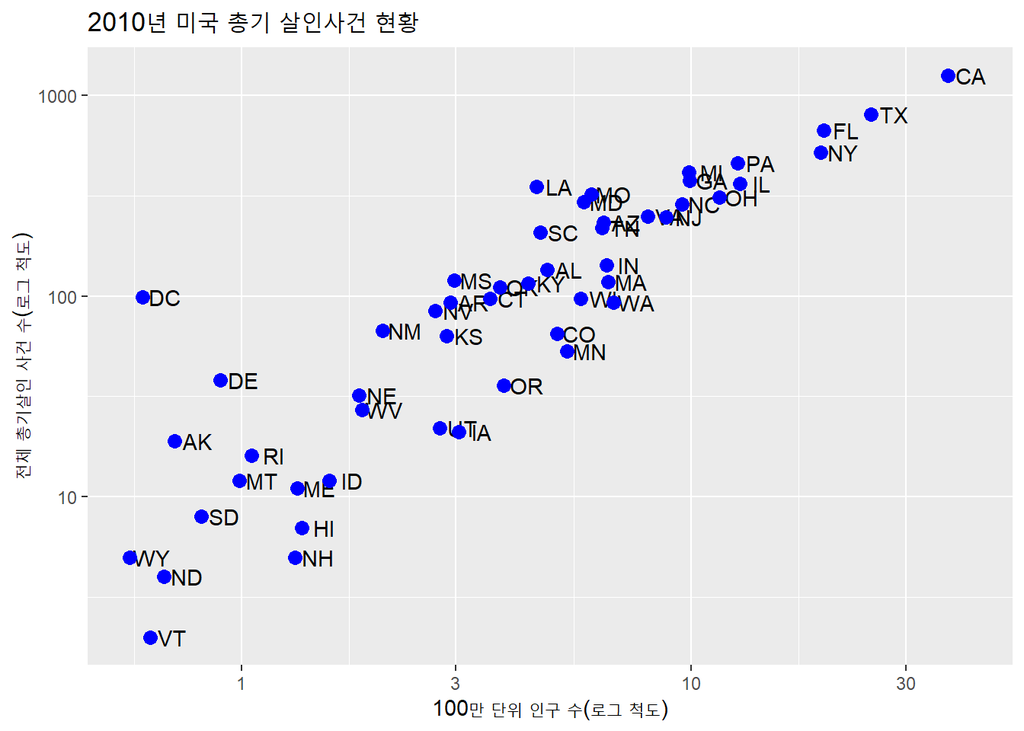

```r
# 모든 포인트의 색상을 일괄적으로 파란색으로 바꾸기.
p + geom_point(size = 3, color ="blue")
```

- 범주변수에 색상 할당하기
  - 범주변수(여기서는 `region`)에 색상을 부여하면, 자동적으로 개별 범주마다 서로 다른 색상이 할당되고 범례(legend)가 생성됨.
  - 지역(`region`)마다 다른 색상을 부여하고자 할 경우, `aes` 함수 내 `col` 논항에 `region` 변수를 넣으면 됨.
  - 범례를 플롯에서 지우고 싶으면, `geom_point` 함수에 `show.legend = FALSE` 논항을 추가하면 됨.
  - 범례 변경
    - 제목 변경: region 범주변수에 색상을 할당했으므로, `scale_color_discrete()` 함수에 `name` 논항을 넣어 범례제목을 변경할 수 있음.
    - 텍스트 변경: `scale_color_discrete()` 함수에 `labels` 논항을 넣어 범례 텍스트를 변경할 수 있음.

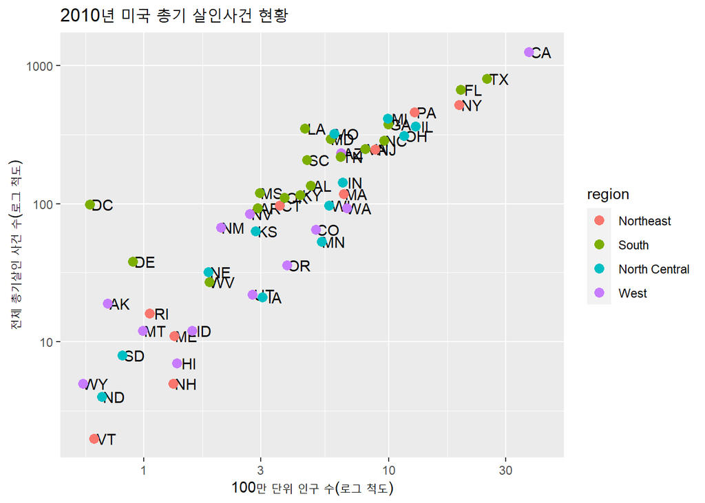

```r
# col 논항을 사용하여 지역마다 서로 다른 색상을 할당하기.
p + geom_point(aes(col=region), size = 3)
```

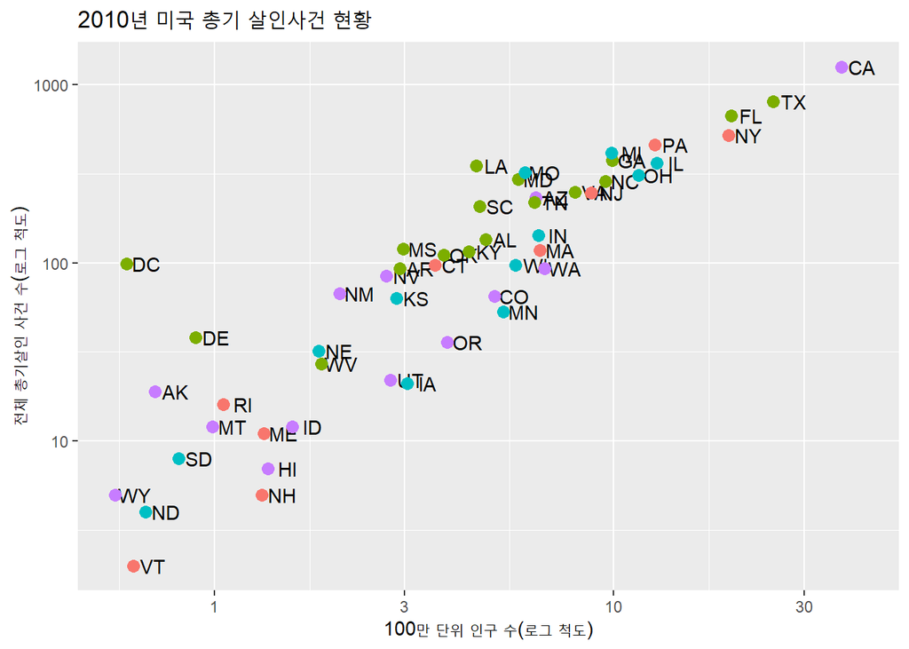

```r
# 범례를 플롯에서 지우고자 할 경우.
p + geom_point(aes(col=region), size = 3, show.legend = FALSE)
```

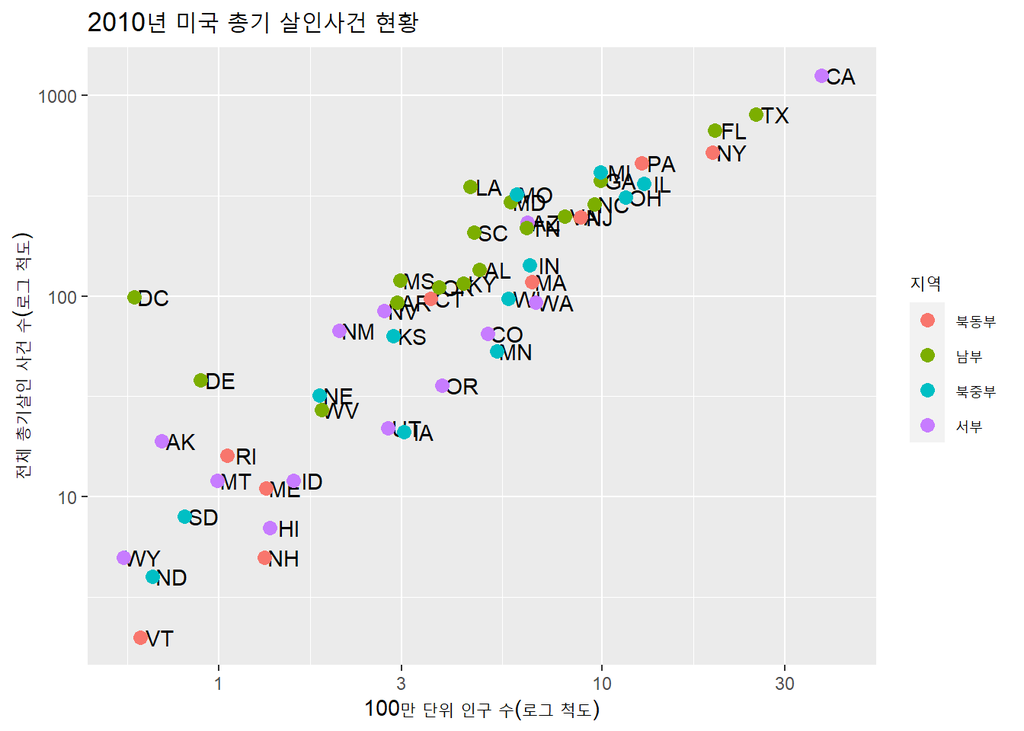

```r
# 범례 제목과 텍스트를 변경하고자 할 경우.
p + geom_point(aes(col=region), size = 3) +
  scale_color_discrete(name = "지역", labels=c("Northeast" = "북동부 ", "North Central" = "북중부",
                                             "South" = "남부", "West" = "서부"))
```

## (13) 미학적 맵핑과 직접적 관련 없는 요소 추가하기

- 미학적 맵핑과 직접적 관련이 없는 요소들도 플롯에 추가 가능. [EX] 주석/레이블, 상자, 그림자, 선 등.
- 예시: 전국의 평균 총기살인율에 해당하는 선 추가하기
  - 단계 1: 인구 100만 명당 총기살인율 *r* 구하기.
  - 단계 2: 100만 단위 인구 수가 x축이고, 총기살인 총 건수가 y축임. 따라서 $y = rx$라는 등식 성립.
  - 단계 3: $y = rx$ 등식은 로그값으로 변환 시 $log(y) = log(r) + log(x)$가 됨. 이에 따라 본 플롯에서는 기울기가 1이고, 절편이 $log(r)$인 선이 생성됨.

```r
# 인구 100만 명당 평균 총기살인 건수 벡터 구하기.
r <- murders %>%
  summarize(rate = sum(total) /  sum(population) * 10^6) %>%
  pull(rate)
```

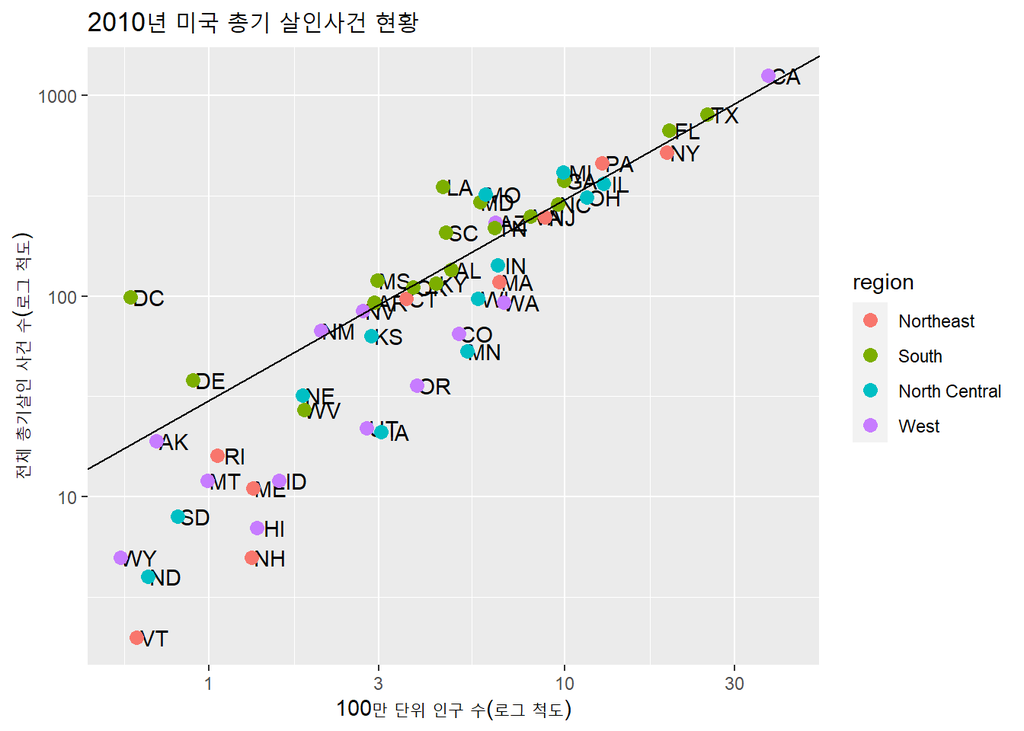

```r
# geom_abline 함수를 통해 인구 100만 명당 평균 총기살인 건수 선 플롯에 추가하기.
p + geom_point(aes(col=region), size = 3) +
  geom_abline(intercept = log10(r))
```

- 선 색상 및 모양 변경
  - 선 색상 변경: `color/colour` 논항 사용.
  - 선 모양 변경: `lty`(line type) 논항 사용.
  - 주의사항: 포인트들이 평균 선 위에 오도록 하고자 할 경우, `geom_abline` 레이어를 `geom_point` 레이어보다 앞서 추가할 것.

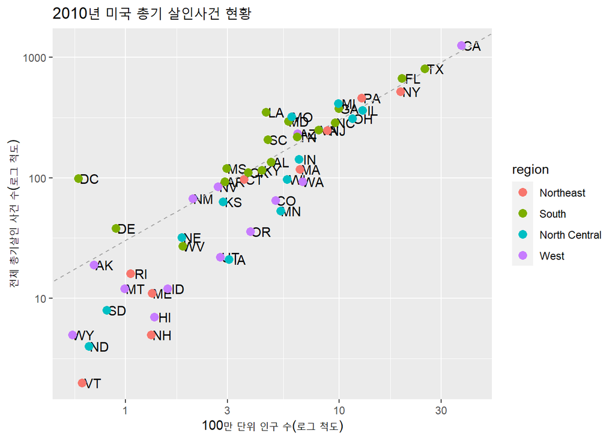

```r
# geom_abline 함수를 통해 인구 100만 명당 평균 총기살인 건수 선 플롯에 추가하기.
p <- p + geom_abline(intercept = log10(r), lty = 2, color = "darkgrey") + # 선 모양 및 색상 변경.
  geom_point(aes(col=region), size = 3)
p
```

## (14) 애드온(add-on) 패키지

- 장점: 그래픽 문법(grammar of graphic)에 따라 개발된 **ggplot2** 기반 애드온 패키지를 사용하면 훨씬 섬세하게 개인화된 맞춤형 플롯을 생성할 수 있음.
- 종류
  - **ggthemes**
    - 테마(theme): 데이터와 무관한 플롯 요소들의 시각적 표현을 정의해줌. **ggplot2**에서는 `theme` 함수로 테마를 정의할 수 있음.
    - 기능: **ggthemes**은 **ggplot2**가 제공하지 않는 다양한 테마를 제공함. [EX] `theme_economist`, `theme_fivethirtyeight`, `theme_wsj` 등.
    - [웹사이트 링크](https://yutannihilation.github.io/allYourFigureAreBelongToUs/ggthemes/): 테마별 구체적 논항 참조.
  - **ggrepel**
    - 기능: 레이블의 위치 변경 및 조정.
    - 본 플롯에서는 일부 레이블이 겹쳐 있어 가독성이 떨어짐. 레이블이 서로 겹치지 않도록 하려면 `geom_text` 함수를 **ggrepel**이 제공하는 `geom_text_repel` 함수로 바꾸면 됨.

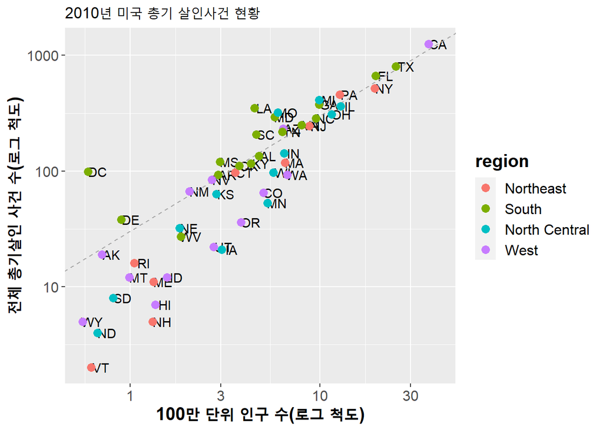

```r
# 테마 및 레이블 위치 변경 애드온 패키지 불러오기.
library(ggthemes)
library(ggrepel)

# ggplot2가 제공하는 기본 theme 함수를 사용하여 테마 정의하기.
p + theme(axis.title=element_text(face="bold", size=15), # x/y축 타이틀 스타일 정의.
          axis.text=element_text(size=12), # x/y축 텍스트 스타일 정의.
          legend.title=element_text(face="bold", size=15), # 범례 제목 스타일 정의.
          legend.text=element_text(size=12), # 범례 텍스트 스타일 정의.
          legend.direction="vertical", # 범례 방향 정의([EX] vertical, horizontal)
          legend.position="right") # 범례 위치 정의([EX] right, left)
```

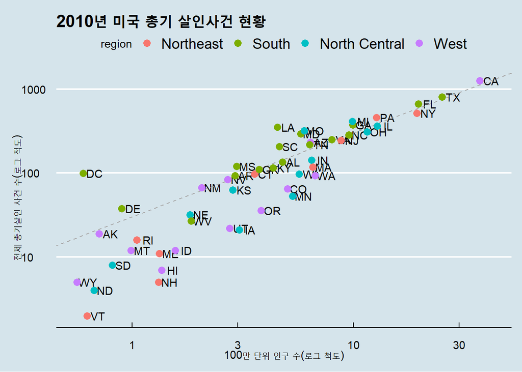

```r
# 기본 테마에서 이코노미스트 테마로 변경하기.
p + theme_economist()
```

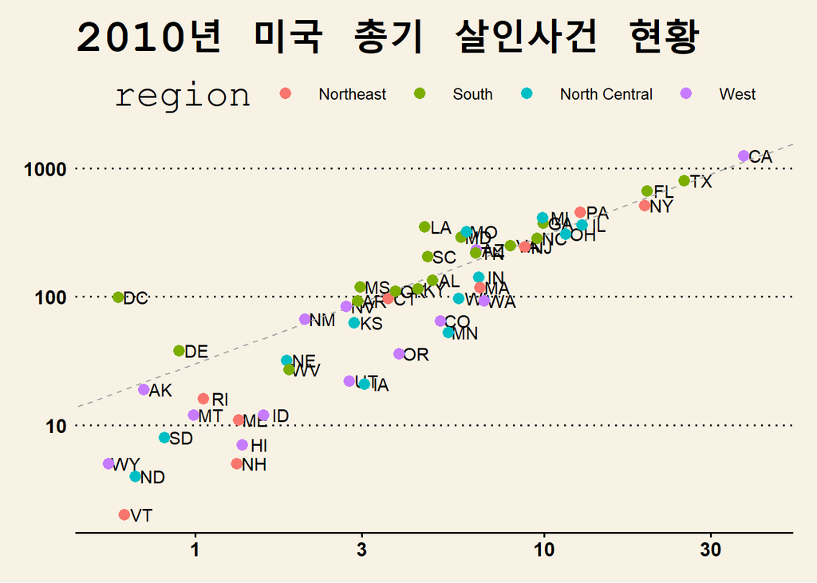

```r
# 기본 테마에서 월스트리트저널 테마로 변경하기.
p + theme_wsj()
```

## (15) **ggplot2**와 애드온 패키지를 사용하여 최종 플롯 완성하기

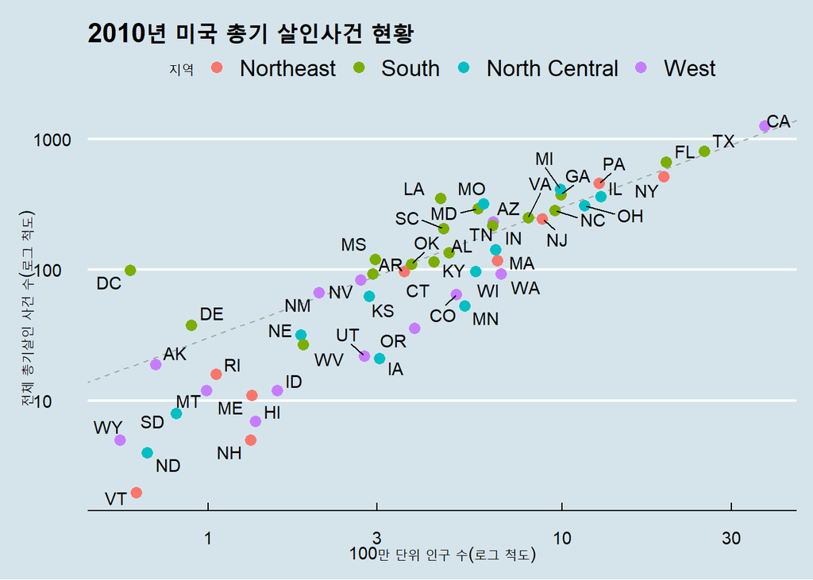

```r
# ggplot2와 애드온 패키지를 바탕으로 최종 플롯 완성하기.
r <- murders %>%
  summarize(rate = sum(total) /  sum(population) * 10^6) %>%
  pull(rate)

murders_plot <- murders %>% ggplot(aes(population/10^6, total, label = abb)) +
  geom_abline(intercept = log10(r), lty = 2, color = "darkgrey") +
  geom_point(aes(col=region), size = 3) +
  geom_text_repel() + # ggrepel 패키지 함수 적용.
  scale_x_log10() +
  scale_y_log10() +
  xlab("100만 단위 인구 수(로그 척도)") +
  ylab("전체 총기살인 사건 수(로그 척도)") +
  ggtitle("2010년 미국 총기 살인사건 현황")+
  scale_color_discrete(name = "지역") +
  theme_economist() # ggthemes 패키지 함수 적용.
murders_plot
```

## (16) 플롯 저장하기

### A. `png` 함수로 저장하기

- 기능: **ggplot2** 플롯을 png 파일 형식으로 저장하기.

```r
# murders_plot 플롯 객체를 png 파일 형식으로 저장하기.
png(filename = "murders_plot.png", width = 1000, height = 1000, type = "cairo",
    antialias = "subpixel", family = "NanumGothic", res = 220)
murders_plot
dev.off()
```

### B. `cairo_pdf` 함수로 저장하기

- 기능: **ggplot2** 플롯을 pdf 파일 형식으로 저장하기.

```r
# murders_plot 플롯 객체를 pdf 파일 형식으로 저장하기.
cairo_pdf(filename = "murders_plot.pdf", width=10, height=5,
          antialias = "subpixel", family="NanumGothic")
murders_plot
dev.off()
```